# 5-HTR Phylogenetic Analysis

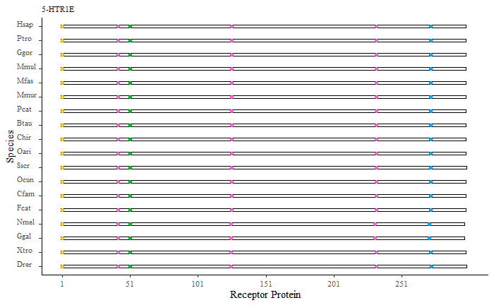

```r
  # plot

  HTR1E_motif_plot <-
    ggplot() +
    scale_y_continuous(breaks = seq(1, 300, 50)) +
    geom_bar(data = HTR1E_vert_data, aes(x = Species, y = Mod_Length), stat = "identity", width = 0.2, col = "black", fill = "white") +
    geom_point(data = HTR1E_vert_data, aes(x = Species, y = Mod_D2.50, colour = "D2.50"), show.legend = FALSE) +
    geom_point(data = HTR1E_vert_data, aes(x =  Species, y = Mod_D3.49, colour = "D3.49"), show.legend = FALSE) +
    geom_point(data = HTR1E_vert_data, aes(x =  Species, y = Mod_N7.49, colour = "N7.49"), show.legend = FALSE) +
    geom_point(data = HTR1E_vert_data, aes(x =  Species, y = Mod_I3.40, colour = "I3.40"), show.legend = FALSE) +
    geom_point(data = HTR1E_vert_data, aes(x =  Species, y = Mod_P5.50, colour = "P5.50"), show.legend = FALSE) +
    geom_point(data = HTR1E_vert_data, aes(x =  Species, y = Mod_F6.44, colour = "F6.44"), show.legend = FALSE) +
    scale_color_manual(values = c("D3.49" = "#00B81F", "N7.49" = "#00A5FF", "D2.50" = "#FFC425", "I3.40" = "#FC61D5", "P5.50" = "#FC61D5", "F6.44" = "#FC61D5"))+
    theme_tufte() +
    theme(axis.line = element_line(),
          axis.text.x = element_text(size = 8),
          axis.text.y = element_text(size = 8, hjust = 0, vjust = 0),
          plot.title = element_text(size = 8),
          panel.background = element_blank(),
          legend.text = element_blank(),
          legend.title = element_blank()) +
    labs(title = "5-HTR1E", y = "Receptor Protein") +
    coord_flip(ylim = c(1, 300)) +
    scale_x_discrete(limits = rev(levels(HTR1E_vert_data$Species)))

  HTR1E_motif_plot
```

```r
################################################################################

# 1F motif plot

  # finding the top limit for the plot

  max(HTR1F_vert_data$Mod_Length, na.rm = T) #323
```

```
[1] 323
```

```r
  # levels

  levels(HTR1F_vert_data$Species)
```

```
 [1] "Hsap" "Ptro" "Ggor" "Mmul" "Mfas" "Cjac" "Mmur" "Mmus" "Rnor" "Pcat" "Btau" "Chir" "Oari" "Sscr" "Ocun" "Cfam"
[17] "Fcat" "Nmel" "Ggal" "Xtro" "Xmac" "Drer"
```

```r
  class(HTR1F_vert_data$Species)
```

```
[1] "factor"
```

```r
  levels(HTR1F_vert_data$Species) <- c(levels(HTR1F_vert_data$Species), "Drer a", "Drer b")

  # renaming double entries

  HTR1F_vert_data[22,"Species"] <- as.character("Drer a")

  HTR1F_vert_data[23,"Species"] <- as.character("Drer b")

  # returning data frame to factor

  HTR1F_vert_data$Species <- factor(HTR1F_vert_data$Species, levels = unique (HTR1F_vert_data$Species))

  class(HTR1F_vert_data$Species)
```

```
[1] "factor"
```

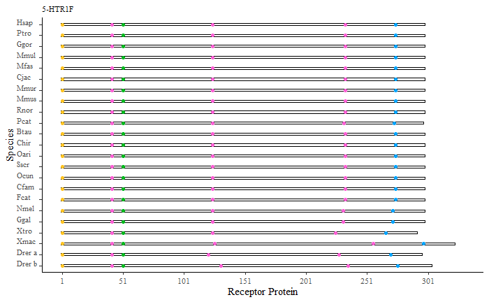

```r
  # plot

  HTR1F_motif_plot <-
    ggplot() +
    scale_y_continuous(breaks = seq(1, 330, 50)) +
    geom_bar(data = HTR1F_vert_data, aes(x = Species, y = Mod_Length), stat = "identity", width = 0.2, col = "black", fill = "white") +
    geom_point(data = HTR1F_vert_data, aes(x = Species, y = Mod_D2.50, colour = "D2.50"), show.legend = FALSE) +
    geom_point(data = HTR1F_vert_data, aes(x =  Species, y = Mod_D3.49, colour = "D3.49"), show.legend = FALSE) +
    geom_point(data = HTR1F_vert_data, aes(x =  Species, y = Mod_N7.49, colour = "N7.49"), show.legend = FALSE) +
    geom_point(data = HTR1F_vert_data, aes(x =  Species, y = Mod_I3.40, colour = "I3.40"), show.legend = FALSE) +
    geom_point(data = HTR1F_vert_data, aes(x =  Species, y = Mod_P5.50, colour = "P5.50"), show.legend = FALSE) +
    geom_point(data = HTR1F_vert_data, aes(x =  Species, y = Mod_F6.44, colour = "F6.44"), show.legend = FALSE) +
    scale_color_manual(values = c("D3.49" = "#00B81F", "N7.49" = "#00A5FF", "D2.50" = "#FFC425", "I3.40" = "#FC61D5", "P5.50" = "#FC61D5", "F6.44" = "#FC61D5"))+
    theme_tufte() +
    theme(axis.line = element_line(),
          axis.text.x = element_text(size = 8),
          axis.text.y = element_text(size = 8, hjust = 0, vjust = 0),
          plot.title = element_text(size = 8),
          panel.background = element_blank(),
          legend.text = element_blank(),
          legend.title = element_blank()) +
    labs(title = "5-HTR1F", y = "Receptor Protein") +
    coord_flip(ylim = c(1, 330)) +
    scale_x_discrete(limits = rev(levels(HTR1F_vert_data$Species)))

  HTR1F_motif_plot
```

```r
################################################################################

# 5A motif plotting

  # 5A length and domains

  # finding the top limit for the plot

  max(HTR5A_vert_data$Mod_Length, na.rm = T) #276
```

```
[1] 276
```

```r
  # levels

  levels(HTR5A_vert_data$Species)
```

```
 [1] "Hsap" "Ptro" "Ggor" "Mmul" "Mfas" "Mmur" "Mmus" "Rnor" "Pcat" "Btau" "Chir" "Ocun" "Cfam" "Fcat" "Nmel" "Ggal"
[17] "Xtro" "Xmac" "Drer"
```

```r
  class(HTR5A_vert_data$Species)
```

```
[1] "factor"
```

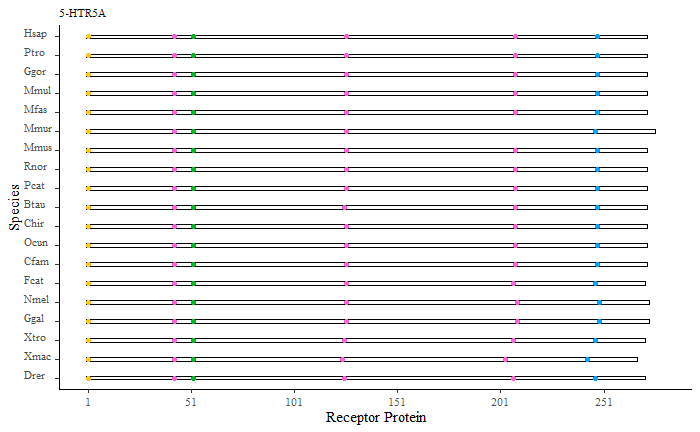

```r
  # plot

  HTR5A_motif_plot <-
    ggplot() +
    scale_y_continuous(breaks = seq(1, 280, 50)) +
    geom_bar(data = HTR5A_vert_data, aes(x = Species, y = Mod_Length), stat = "identity", width = 0.2, col = "black", fill = "white") +
    geom_point(data = HTR5A_vert_data, aes(x = Species, y = Mod_D2.50, colour = "D2.50"), show.legend = FALSE) +
    geom_point(data = HTR5A_vert_data, aes(x =  Species, y = Mod_D3.49, colour = "D3.49"), show.legend = FALSE) +
    geom_point(data = HTR5A_vert_data, aes(x =  Species, y = Mod_N7.49, colour = "N7.49"), show.legend = FALSE) +
    geom_point(data = HTR5A_vert_data, aes(x =  Species, y = Mod_I3.40, colour = "I3.40"), show.legend = FALSE) +
    geom_point(data = HTR5A_vert_data, aes(x =  Species, y = Mod_P5.50, colour = "P5.50"), show.legend = FALSE) +
    geom_point(data = HTR5A_vert_data, aes(x =  Species, y = Mod_F6.44, colour = "F6.44"), show.legend = FALSE) +
    scale_color_manual(values = c("D3.49" = "#00B81F", "N7.49" = "#00A5FF", "D2.50" = "#FFC425", "I3.40" = "#FC61D5", "P5.50" = "#FC61D5", "F6.44" = "#FC61D5"))+
    theme_tufte() +
    theme(axis.line = element_line(),
          axis.text.x = element_text(size = 8),
          axis.text.y = element_text(size = 8, hjust = 0, vjust = 0),
          plot.title = element_text(size = 8),
          panel.background = element_blank(),
          legend.text = element_blank(),
          legend.title = element_blank()) +
    labs(title = "5-HTR5A", y ="Receptor Protein") +
    coord_flip(ylim = c(1, 280)) +
    scale_x_discrete(limits = rev(levels(HTR5A_vert_data$Species)))

  HTR5A_motif_plot
```

```r
################################################################################

  # 5B length and domains

  # finding the top limit for the plot

  max(HTR5B_vert_data$Mod_Length, na.rm = T) #273
```

```
[1] 273
```

```r
  # levels

  levels(HTR5B_vert_data$Species)
```

```
 [1] "Ptro" "Ggor" "Mmul" "Mfas" "Cjac" "Mmur" "Mmus" "Rnor" "Btau" "Chir" "Fcat"
```

```r
  class(HTR5B_vert_data$Species)
```

```
[1] "factor"
```

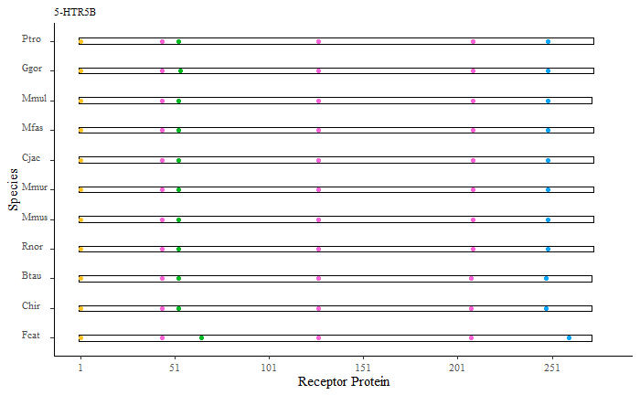

```r
  # plot

  HTR5B_motif_plot <-
    ggplot() +
    scale_y_continuous(breaks = seq(1, 280, 50)) +
    geom_bar(data = HTR5B_vert_data, aes(x = Species, y = Mod_Length), stat = "identity", width = 0.2, col = "black", fill = "white") +
    geom_point(data = HTR5B_vert_data, aes(x = Species, y = Mod_D2.50, colour = "D2.50"), show.legend = FALSE) +
    geom_point(data = HTR5B_vert_data, aes(x =  Species, y = Mod_D3.49, colour = "D3.49"), show.legend = FALSE) +
    geom_point(data = HTR5B_vert_data, aes(x =  Species, y = Mod_N7.49, colour = "N7.49"), show.legend = FALSE) +
    geom_point(data = HTR5B_vert_data, aes(x =  Species, y = Mod_I3.40, colour = "I3.40"), show.legend = FALSE) +
    geom_point(data = HTR5B_vert_data, aes(x =  Species, y = Mod_P5.50, colour = "P5.50"), show.legend = FALSE) +
    geom_point(data = HTR5B_vert_data, aes(x =  Species, y = Mod_F6.44, colour = "F6.44"), show.legend = FALSE) +
    scale_color_manual(values = c("D3.49" = "#00B81F", "N7.49" = "#00A5FF", "D2.50" = "#FFC425", "I3.40" = "#FC61D5", "P5.50" = "#FC61D5", "F6.44" = "#FC61D5"))+
    theme_tufte() +
    theme(axis.line = element_line(),
          axis.text.x = element_text(size = 8),
          axis.text.y = element_text(size = 8, hjust = 0, vjust = 0),
          plot.title = element_text(size = 8),
          panel.background = element_blank(),
          legend.text = element_blank(),
          legend.title = element_blank()) +
    labs(title = "5-HTR5B", y ="Receptor Protein") +
    coord_flip(ylim = c(1, 280)) +
    scale_x_discrete(limits = rev(levels(HTR5B_vert_data$Species)))

  HTR5B_motif_plot
```

```r
################################################################################

  # 6 motif plotting

  # finding the top limit for the plot

  max(HTR6_vert_data$Mod_Length, na.rm = T) # 393
```

```
[1] 393
```

```r
  # levels

  levels(HTR6_vert_data$Species)
```

```
 [1] "Hsap" "Ptro" "Ggor" "Mmul" "Mfas" "Cjac" "Mmur" "Mmus" "Rnor" "Pcat" "Btau" "Chir" "Oari" "Sscr" "Cfam" "Fcat"
[17] "Nmel" "Ggal" "Xtro" "Xmac" "Drer"
```

```r
  class(HTR6_vert_data$Species)
```

```
[1] "factor"
```

```r
  levels(HTR6_vert_data$Species) <- c(levels(HTR6_vert_data$Species), "Xmac X1", "Xmac X2")

  # renaming double entries

  HTR6_vert_data[19,"Species"] <- as.character("Xmac X1")

  HTR6_vert_data[20,"Species"] <- as.character("Xmac X2")

  # returning data frame to factor

  HTR6_vert_data$Species <- factor(HTR6_vert_data$Species, levels = unique (HTR6_vert_data$Species))

  class(HTR6_vert_data$Species)
```

```
[1] "factor"
```

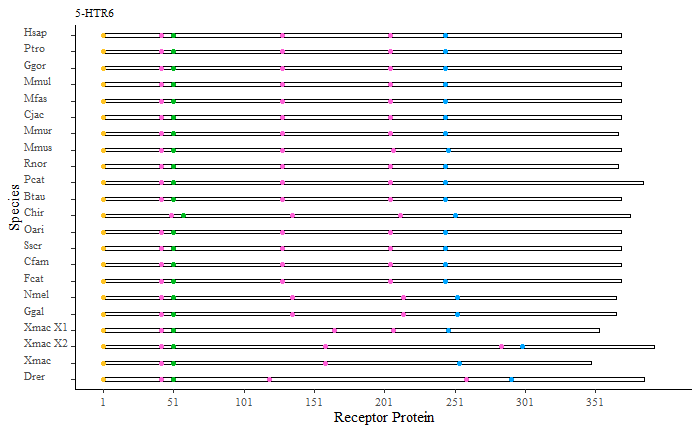

```r
  # plot

    HTR6_motif_plot <-
    ggplot() +
    scale_y_continuous(breaks = seq(1, 400, 50)) +
    geom_bar(data = HTR6_vert_data, aes(x = Species, y = Mod_Length), stat = "identity", width = 0.2, col = "black", fill = "white") +
    geom_point(data = HTR6_vert_data, aes(x = Species, y = Mod_D2.50, colour = "D2.50"), show.legend = FALSE) +
    geom_point(data = HTR6_vert_data, aes(x =  Species, y = Mod_D3.49, colour = "D3.49"), show.legend = FALSE) +
    geom_point(data = HTR6_vert_data, aes(x =  Species, y = Mod_N7.49, colour = "N7.49"), show.legend = FALSE) +
    geom_point(data = HTR6_vert_data, aes(x =  Species, y = Mod_I3.40, colour = "I3.40"), show.legend = FALSE) +
    geom_point(data = HTR6_vert_data, aes(x =  Species, y = Mod_P5.50, colour = "P5.50"), show.legend = FALSE) +
    geom_point(data = HTR6_vert_data, aes(x =  Species, y = Mod_F6.44, colour = "F6.44"), show.legend = FALSE) +
    scale_color_manual(values = c("D3.49" = "#00B81F", "N7.49" = "#00A5FF", "D2.50" = "#FFC425", "I3.40" = "#FC61D5", "P5.50" = "#FC61D5", "F6.44" = "#FC61D5"))+
    theme_tufte() +
    theme(axis.line = element_line(),
          axis.text.x = element_text(size = 8),
          axis.text.y = element_text(size = 8, hjust = 0, vjust = 0),
          plot.title = element_text(size = 8),
          panel.background = element_blank(),
          legend.text = element_blank(),
          legend.title = element_blank()) +
    labs(title = "5-HTR6", y ="Receptor Protein") +
    coord_flip(ylim = c(1, 400)) +
    scale_x_discrete(limits = rev(levels(HTR6_vert_data$Species)))

  HTR6_motif_plot
```

```r
################################################################################

  # 2C motif plotting

  # 2C length and domains

  # finding the top limit for the plot

    max(HTR2C_new_data$Mod_Length,na.rm = T) # 405
```

```
[1] 405
```

```r
  # levels

    levels(HTR2C_new_data$Species)
```

```
 [1] "Hsap" "Ptro" "Ggor" "Mmul" "Mfas" "Cjac" "Mmur" "Mmus" "Rnor" "Pcat" "Chir" "Oari" "Sscr" "Ocun" "Cfam" "Fcat"
[17] "Nmel" "Ggal" "Xtro" "Drer"
```

```r
    class(HTR2C_new_data$Species)
```

```
[1] "factor"
```

```r
  # returning data frame to factor

    HTR2C_new_data$Species <- factor(HTR2C_new_data$Species, levels = unique (HTR2C_new_data$Species))

    class(HTR2C_new_data$Species)
```

```
[1] "factor"
```

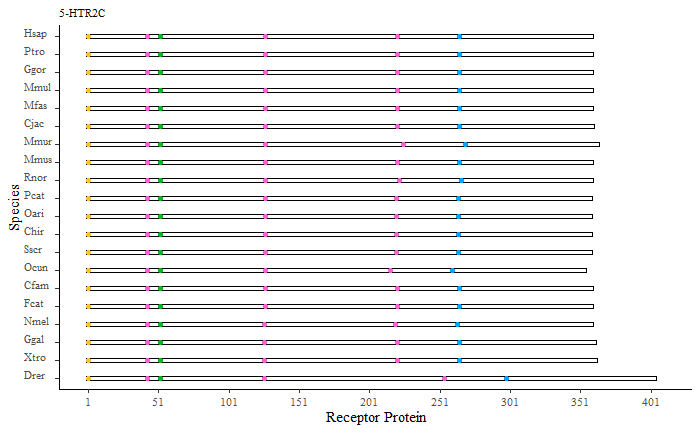

```r
  # plot

  HTR2C_motif_plot <-
    ggplot() +
    scale_y_continuous(breaks = seq(1, 410, 50)) +
    geom_bar(data = HTR2C_new_data, aes(x = Species, y = Mod_Length), stat = "identity", width = 0.2, col = "black", fill = "white") +
    geom_point(data = HTR2C_new_data, aes(x = Species, y = Mod_D2.50, colour = "D2.50"), show.legend = FALSE) +
    geom_point(data = HTR2C_new_data, aes(x =  Species, y = Mod_D3.49, colour = "D3.49"), show.legend = FALSE) +
    geom_point(data = HTR2C_new_data, aes(x =  Species, y = Mod_N7.49, colour = "N7.49"), show.legend = FALSE) +
    geom_point(data = HTR2C_new_data, aes(x =  Species, y = Mod_I3.40, colour = "I3.40"), show.legend = FALSE) +
    geom_point(data = HTR2C_new_data, aes(x =  Species, y = Mod_P5.50, colour = "P5.50"), show.legend = FALSE) +
    geom_point(data = HTR2C_new_data, aes(x =  Species, y = Mod_F6.44, colour = "F6.44"), show.legend = FALSE) +
    scale_color_manual(values = c("D3.49" = "#00B81F", "N7.49" = "#00A5FF", "D2.50" = "#FFC425", "I3.40" = "#FC61D5", "P5.50" = "#FC61D5", "F6.44" = "#FC61D5"))+
    theme_tufte() +
    theme(axis.line = element_line(),
          axis.text.x = element_text(size = 8),
          axis.text.y = element_text(size = 8, hjust = 0, vjust = 0),
          plot.title = element_text(size = 8),
          panel.background = element_blank(),
          legend.text = element_blank(),
          legend.title = element_blank()) +
    labs(title = "5-HTR2C", y ="Receptor Protein") +
    coord_flip(ylim = c(1, 410)) +
    scale_x_discrete(limits = rev(levels(HTR2C_new_data$Species)))

  HTR2C_motif_plot
```

```r
################################################################################

  # plotting 2B motifs

  # finding the top limit for the plot

    max(HTR2B_new_data$Mod_Length, na.rm = T) #402
```

```
[1] 402
```

```r
  # levels

    levels(HTR2B_new_data$Species)
```

```
 [1] "Hsap" "Ptro" "Ggor" "Mmul" "Mfas" "Cjac" "Mmur" "Mmus" "Rnor" "Pcat" "Btau" "Chir" "Oari" "Sscr" "Ocun" "Cfam"
[17] "Fcat" "Nmel" "Ggal" "Xtro" "Xmac" "Drer"
```

```r
    levels(HTR2B_new_data$Name)
```

```
 [1] "5-HTR2B_human_1"          "5-HTR2B_human_2"          "5-HTR2B_chimpanzee_X1"    "5-HTR2B_chimpanzee_X3"
 [5] "5-HTR2B_gorilla_X1"       "5-HTR2B_gorilla_X2"       "5-HTR2B_rhesus_monkey_X1" "5-HTR2B_rhesus_monkey_X2"
 [9] "5-HTR2B_macaque_X1"       "5-HTR2B_marmoset_X1"      "5-HTR2B_marmoset_X2"      "5-HTR2B_lemur_X1"
[13] "5-HTR2B_lemur_X2"         "5-HTR2B_mouse"            "5-HTR2B_rat"              "5-HTR2B_sperm_whale"
[17] "5-HTR2B_cow"              "5-HTR2B_goat"             "5-HTR2B_sheep_X1"         "5-HTR2B_sheep_X2"
[21] "5-HTR2B_pig"              "5-HTR2B_pig_X2"           "5-HTR2B_rabbit_X1"        "5-HTR2B_rabbit_X2"
[25] "5-HTR2B_dog"              "5-HTR2B_cat"              "5-HTR2B_guineafowl"       "5-HTR2B_chicken"
[29] "5-HTR2B_clawed_frog"      "5-HTR2B_platyfish"        "5-HTR2B_zebrafish"
```

```r
    class(HTR2B_new_data$Species)
```

```
[1] "factor"
```

```r
  # returning data frame to factor

      HTR2B_new_data$Species <- factor(HTR2B_new_data$Species, levels = unique (HTR2B_new_data$Species))

      class(HTR2B_new_data$Species)
```

```
[1] "factor"
```

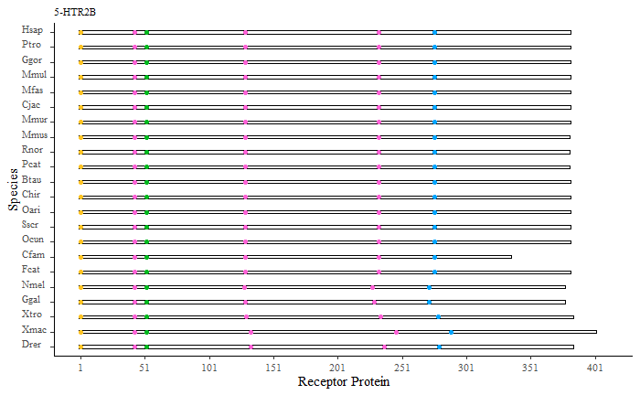

```r
  # plot

  HTR2B_motif_plot <-
    ggplot() +
    scale_y_continuous(breaks = seq(1, 410, 50)) +
    geom_bar(data = HTR2B_new_data, aes(x = Species, y = Mod_Length), stat = "identity", width = 0.2, col = "black", fill = "white") +
    geom_point(data = HTR2B_new_data, aes(x = Species, y = Mod_D2.50, colour = "D2.50"), show.legend = FALSE) +
    geom_point(data = HTR2B_new_data, aes(x =  Species, y = Mod_D3.49, colour = "D3.49"), show.legend = FALSE) +
    geom_point(data = HTR2B_new_data, aes(x =  Species, y = Mod_N7.49, colour = "N7.49"), show.legend = FALSE) +
    geom_point(data = HTR2B_new_data, aes(x =  Species, y = Mod_I3.40, colour = "I3.40"), show.legend = FALSE) +
    geom_point(data = HTR2B_new_data, aes(x =  Species, y = Mod_P5.50, colour = "P5.50"), show.legend = FALSE) +
    geom_point(data = HTR2B_new_data, aes(x =  Species, y = Mod_F6.44, colour = "F6.44"), show.legend = FALSE) +
    scale_color_manual(values = c("D3.49" = "#00B81F", "N7.49" = "#00A5FF", "D2.50" = "#FFC425", "I3.40" = "#FC61D5", "P5.50" = "#FC61D5", "F6.44" = "#FC61D5"))+
    theme_tufte() +
    theme(axis.line = element_line(),
          axis.text.x = element_text(size = 8),
          axis.text.y = element_text(size = 8, hjust = 0, vjust = 0),
          plot.title = element_text(size = 8),
          panel.background = element_blank(),
          legend.text = element_blank(),
          legend.title = element_blank()) +
    labs(title = "5-HTR2B", y ="Receptor Protein") +
    coord_flip(ylim = c(1, 410)) +
    scale_x_discrete(limits = rev(levels(HTR2B_new_data$Species)))

  HTR2B_motif_plot
```

```r
################################################################################

# 2A motif plot

# finding the top limit for the plot

  max(HTR2A_vert_data$Length, na.rm = T) # 496
```

```
[1] 496
```

```r
# levels

  levels(HTR2A_vert_data$Species)
```

```
 [1] "Hsap" "Ptro" "Ggor" "Mmul" "Mfas" "Cjac" "Mmur" "Mmus" "Rnor" "Pcat" "Btau" "Chir" "Oari" "Sscr" "Ocun" "Cfam"
[17] "Fcat" "Nmel" "Ggal" "Xtro" "Xmac" "Drer"
```

```r
  class(HTR2A_vert_data$Species)
```

```
[1] "factor"
```

```r
  levels(HTR2A_vert_data$Species) <- c(levels(HTR2A_vert_data$Species),
                                     "Hsap 1",
                                     "Hsap 2",
                                     "Ptro X1",
                                     "Ptro X2",
                                     "Ggor",
                                     "Mmul X1",
                                     "Mmul X2",
                                     "Mfas X1",
                                     "Mfas X2",
                                     "Cjac",
                                     "Mmur X1",
                                     "Mmur X2")

# renaming double entries

  HTR2A_vert_data[1,"Species"] <- as.character("Hsap 1")

  HTR2A_vert_data[2,"Species"] <- as.character("Hsap 2")

  HTR2A_vert_data[3,"Species"] <- as.character("Ptro X1")

  HTR2A_vert_data[4,"Species"] <- as.character("Ptro X2")

  HTR2A_vert_data[6,"Species"] <- as.character("Mmul X1")

  HTR2A_vert_data[7,"Species"] <- as.character("Mmul X2")

  HTR2A_vert_data[8,"Species"] <- as.character("Mfas X1")

  HTR2A_vert_data[9,"Species"] <- as.character("Mfas X2")

  HTR2A_vert_data[11,"Species"] <- as.character("Mmur X1")

  HTR2A_vert_data[12,"Species"] <- as.character("Mmur X2")

# returning data frame to factor

  HTR2A_vert_data$Species <- factor(HTR2A_vert_data$Species, levels = unique (HTR2A_vert_data$Species))

  class(HTR2A_vert_data$Species)
```

```
[1] "factor"
```

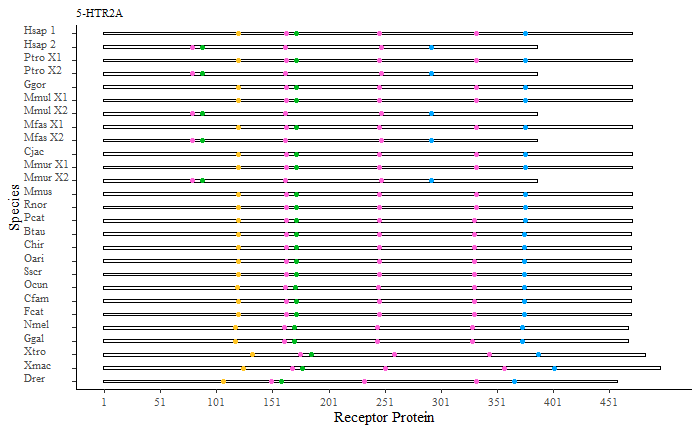

```r
# plot

  HTR2A_motif_plot <-
  ggplot() +
  scale_y_continuous(breaks = seq(1, 500, 50)) +
  geom_bar(data = HTR2A_vert_data, aes(x = Species, y = Length), stat = "identity", width = 0.2, col = "black", fill = "white") +
  geom_point(data = HTR2A_vert_data, aes(x = Species, y = D2.50, colour = "D2.50"), show.legend = FALSE) +
  geom_point(data = HTR2A_vert_data, aes(x =  Species, y = D3.49, colour = "D3.49"), show.legend = FALSE) +
  geom_point(data = HTR2A_vert_data, aes(x =  Species, y = N7.49, colour = "N7.49"), show.legend = FALSE) +
  geom_point(data = HTR2A_vert_data, aes(x =  Species, y = I3.40, colour = "I3.40"), show.legend = FALSE) +
  geom_point(data = HTR2A_vert_data, aes(x =  Species, y = P5.50, colour = "P5.50"), show.legend = FALSE) +
  geom_point(data = HTR2A_vert_data, aes(x =  Species, y = F6.44, colour = "F6.44"), show.legend = FALSE) +
  scale_color_manual(values = c("D3.49" = "#00B81F", "N7.49" = "#00A5FF", "D2.50" = "#FFC425", "I3.40" = "#FC61D5", "P5.50" = "#FC61D5", "F6.44" = "#FC61D5"))+
  theme_tufte() +
  theme(axis.line = element_line(),
        axis.text.x = element_text(size = 8),
        axis.text.y = element_text(size = 8, hjust = 0, vjust = 0),
        plot.title = element_text(size = 8),
        panel.background = element_blank(),
        legend.text = element_blank(),
        legend.title = element_blank()) +
    labs(title = "5-HTR2A", y ="Receptor Protein") +
    coord_flip(ylim = c(1, 500)) +
  scale_x_discrete(limits = rev(levels(HTR2A_vert_data$Species)))

HTR2A_motif_plot
```

```r
################################################################################

# 7 motif plot

  # finding the top limit for the plot

    max(HTR7_vert_data$Mod_Length, na.rm = T) #376
```

```
[1] 376
```

```r
  # levels

    levels(HTR7_vert_data$Species)
```

```
 [1] "Hsap" "Ptro" "Ggor" "Mmul" "Mfas" "Cjac" "Mmur" "Mmus" "Rnor" "Pcat" "Btau" "Chir" "Oari" "Sscr" "Ocun" "Cfam"
[17] "Fcat" "Nmel" "Ggal" "Xtro" "Xmac" "Drer"
```

```r
    class(HTR7_vert_data$Species)
```

```
[1] "factor"
```

```r
    levels(HTR7_vert_data$Name)
```

```
 [1] "5-HTR7_human_a"          "5-HTR7_human_b"          "5-HTR7_human_d"          "5-HTR7_chimpanzee"
 [5] "5-HTR7_chimpanzee_X1"    "5-HTR7_chimpanzee_X2"    "5-HTR7_gorilla_X1"       "5-HTR7_gorilla_X2"
 [9] "5-HTR7_rhesus_monkey_X1" "5-HTR7_rhesus_monkey_X2" "5-HTR7_rhesus_monkey_X3" "5-HTR7_macaque_X1"
[13] "5-HTR7_macaque_X2"       "5-HTR7_macaque_X3"       "5-HTR7_marmoset_X1"      "5-HTR7_marmoset_X2"
[17] "5-HTR7_marmoset_X3"      "5-HTR7_marmoset_X4"      "5-HTR7_lemur_X1"         "5-HTR7_lemur_X2"
[21] "5-HTR7_lemur_X3"         "5-HTR7_mouse_1"          "5-HTR7_mouse_2"          "5-HTR7_mouse_3"
[25] "5-HTR7_rat"              "5-HTR7_rat_X1"           "5-HTR7_rat_X2"           "5-HTR7_sperm_whale"
[29] "5-HTR7_cow_X1"           "5-HTR7_cow_X2"           "5-HTR7_goat"             "5-HTR7_sheep"
[33] "5-HTR7_pig"              "5-HTR7_pig_X1"           "5-HTR7_pig_X2"           "5-HTR7_rabbit_X1"
[37] "5-HTR7_rabbit_X2"        "5-HTR7_dog_X1"           "5-HTR7_dog_X2"           "5-HTR7_cat_X1"
[41] "5-HTR7_cat_X2"           "5-HTR7_cat_X3"           "5-HTR7_guineafowl"       "5-HTR7_chicken_X1"
[45] "5-HTR7_chicken_X2"       "5-HTR7_chicken_X3"       "5-HTR7_xenopus"          "5-HTR7_platyfish"
[49] "5-HTR7_zebrafish"
```

```r
    levels(HTR7_vert_data$Species) <- c(levels(HTR7_vert_data$Species),
                                      "Hsap a",
                                      "Hsap b",
                                      "Hsap d",
                                      "Ptro X1",
                                      "Ptro X2",
                                      "Ggor X1",
                                      "Ggor X2",
                                      "Mmul X1",
                                      "Mmul X2",
                                      "Mmul X3",
                                      "Mfas X1",
                                      "Mfas X2",
                                      "Mfas X3",
                                      "Cjac X1",
                                      "Cjac X2",
                                      "Cjac X3",
                                      "Cjac X4",
                                      "Mmur X1",
                                      "Mmur X2",
                                      "Mmur X3",
                                      "Mmus 1",
                                      "Mmus 2",
                                      "Mmus 3",
                                      "Rnor X1",
                                      "Rnor X2",
                                      "Btau X1",
                                      "Btau X2",
                                      "Sscr X1",
                                      "Sscr X2",
                                      "Ocun X1",
                                      "Ocun X2",
                                      "Cfam X1",
                                      "Cfam X2",
                                      "Fcat X1",
                                      "Fcat X2",
                                      "Fcat X3",
                                      "Ggal X1",
                                      "Ggal X2",
                                      "Ggal X3" )

  # renaming double entries

    HTR7_vert_data[1,"Species"] <- as.character("Hsap a")

    HTR7_vert_data[2,"Species"] <- as.character("Hsap b")

    HTR7_vert_data[3,"Species"] <- as.character("Hsap d")

    HTR7_vert_data[5,"Species"] <- as.character("Ptro X1")

    HTR7_vert_data[6,"Species"] <- as.character("Ptro X2")

    HTR7_vert_data[7,"Species"] <- as.character("Ggor X1")

    HTR7_vert_data[8,"Species"] <- as.character("Ggor X2")

    HTR7_vert_data[9,"Species"] <- as.character("Mmul X1")

    HTR7_vert_data[10,"Species"] <- as.character("Mmul X2")

    HTR7_vert_data[11,"Species"] <- as.character("Mmul X3")

    HTR7_vert_data[12,"Species"] <- as.character("Mfas X1")

    HTR7_vert_data[13,"Species"] <- as.character("Mfas X2")

    HTR7_vert_data[14,"Species"] <- as.character("Mfas X3")

    HTR7_vert_data[15,"Species"] <- as.character("Cjac X1")

    HTR7_vert_data[16,"Species"] <- as.character("Cjac X2")

    HTR7_vert_data[17,"Species"] <- as.character("Cjac X3")

    HTR7_vert_data[18,"Species"] <- as.character("Cjac X4")

    HTR7_vert_data[19,"Species"] <- as.character("Mmur X1")

    HTR7_vert_data[20,"Species"] <- as.character("Mmur X2")

    HTR7_vert_data[21,"Species"] <- as.character("Mmur X3")

    HTR7_vert_data[22,"Species"] <- as.character("Mmus 1")

    HTR7_vert_data[23,"Species"] <- as.character("Mmus 2")

    HTR7_vert_data[24,"Species"] <- as.character("Mmus 3")

    HTR7_vert_data[26,"Species"] <- as.character("Rnor X1")

    HTR7_vert_data[27,"Species"] <- as.character("Rnor X2")

    HTR7_vert_data[29,"Species"] <- as.character("Btau X1")

    HTR7_vert_data[30,"Species"] <- as.character("Btau X2")

    HTR7_vert_data[34,"Species"] <- as.character("Sscr X1")

    HTR7_vert_data[35,"Species"] <- as.character("Sscr X2")

    HTR7_vert_data[36,"Species"] <- as.character("Ocun X1")

    HTR7_vert_data[37,"Species"] <- as.character("Ocun X2")

    HTR7_vert_data[38,"Species"] <- as.character("Cfam X1")

    HTR7_vert_data[39,"Species"] <- as.character("Cfam X2")

    HTR7_vert_data[40,"Species"] <- as.character("Fcat X1")

    HTR7_vert_data[41,"Species"] <- as.character("Fcat X2")

    HTR7_vert_data[42,"Species"] <- as.character("Fcat X3")

    HTR7_vert_data[44,"Species"] <- as.character("Ggal X1")

    HTR7_vert_data[45,"Species"] <- as.character("Ggal X2")

    HTR7_vert_data[46,"Species"] <- as.character("Ggal X3")

  # returning data frame to factor

   HTR7_vert_data$Species <- factor(HTR7_vert_data$Species, levels = unique (HTR7_vert_data$Species))


   class(HTR7_vert_data$Species)
```

```
[1] "factor"
```

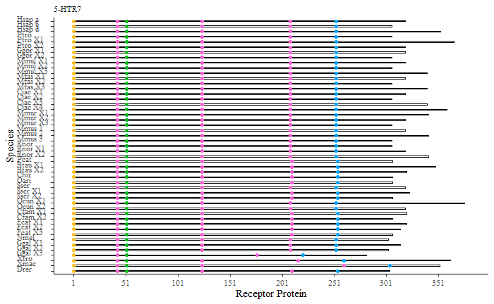

```r
  # plot

   HTR7_motif_plot <-
    ggplot() +
    scale_y_continuous(breaks = seq(1, 380, 50)) +
    geom_bar(data = HTR7_vert_data, aes(x = Species, y = Mod_Length), stat = "identity", width = 0.2, col = "black", fill = "white") +
    geom_point(data = HTR7_vert_data, aes(x = Species, y = Mod_D2.50, colour = "D2.50"), show.legend = FALSE) +
    geom_point(data = HTR7_vert_data, aes(x =  Species, y = Mod_D3.49, colour = "D3.49"), show.legend = FALSE) +
    geom_point(data = HTR7_vert_data, aes(x =  Species, y = Mod_N7.49, colour = "N7.49"), show.legend = FALSE) +
    geom_point(data = HTR7_vert_data, aes(x =  Species, y = Mod_I3.40, colour = "I3.40"), show.legend = FALSE) +
    geom_point(data = HTR7_vert_data, aes(x =  Species, y = Mod_P5.50, colour = "P5.50"), show.legend = FALSE) +
    geom_point(data = HTR7_vert_data, aes(x =  Species, y = Mod_F6.44, colour = "F6.44"), show.legend = FALSE) +
    scale_color_manual(values = c("D3.49" = "#00B81F", "N7.49" = "#00A5FF", "D2.50" = "#FFC425", "I3.40" = "#FC61D5", "P5.50" = "#FC61D5", "F6.44" = "#FC61D5"))+
    theme_tufte() +
    theme(axis.line = element_line(),
          axis.text.x = element_text(size = 8),
          axis.text.y = element_text(size = 8, hjust = 0, vjust = 0),
          plot.title = element_text(size = 8),
          panel.background = element_blank(),
          legend.text = element_blank(),
          legend.title = element_blank()) +
     labs(title = "5-HTR7", y ="Receptor Protein") +
    coord_flip(ylim = c(1, 380)) +
    scale_x_discrete(limits = rev(levels(HTR7_vert_data$Species)))

  HTR7_motif_plot
```

```r
################################################################################

# 4 motif plot

  # finding the top limit for the plot

   max(HTR4_vert_data$Mod_Length, na.rm = T) # 363
```

```
[1] 363
```

```r
  # levels

   levels(HTR4_vert_data$Species)
```

```
 [1] "Hsap" "Ptro" "Ggor" "Mmul" "Mfas" "Cjac" "Mmur" "Mmus" "Rnor" "Pcat" "Btau" "Chir" "Oari" "Sscr" "Ocun" "Cfam"
[17] "Fcat" "Nmel" "Ggal" "Xtro" "Xmac" "Drer"
```

```r
   class(HTR4_vert_data$Species)
```

```
[1] "factor"
```

```r
   levels(HTR4_vert_data$Species) <- c(levels(HTR4_vert_data$Species),
                                      "Hsap a",
                                      "Hsap b",
                                      "Hsap c",
                                      "Hsap d",
                                      "Hsap g",
                                      "Hsap i",
                                      "Ptro X1",
                                      "Ptro X2",
                                      "Ptro X3",
                                      "Ptro X4",
                                      "Ggor X1",
                                      "Ggor X2",
                                      "Mmul X1",
                                      "Mmul X2",
                                      "Mmul X3",
                                      "Mfas X1",
                                      "Mfas X2",
                                      "Mfas X3",
                                      "Mfas X4",
                                      "Cjac X1",
                                      "Cjac X2",
                                      "Mmur X1",
                                      "Mmur X2",
                                      "Mmur X3",
                                      "Mmur X4",
                                      "Mmus 1",
                                      "Mmus 2",
                                      "Mmus 3",
                                      "Mmus 4",
                                      "Mmus 5",
                                      "Rnor X1",
                                      "Rnor X2",
                                      "Pcat X1",
                                      "Pcat X2",
                                      "Pcat X3",
                                      "Btau X1",
                                      "Btau X2",
                                      "Btau X3",
                                      "Btau X4",
                                      "Chir X1",
                                      "Chir X2",
                                      "Ocun X1",
                                      "Ocun X2",
                                      "Cfam X1",
                                      "Cfam X2",
                                      "Cfam X3",
                                      "Fcat X1",
                                      "Fcat X2",
                                      "Fcat X3",
                                      "Nmel X1",
                                      "Nmel X2",
                                      "Nmel X3",
                                      "Ggal X1",
                                      "Ggal X2",
                                      "Xmac X1",
                                      "Xmac X2",
                                      "Xmac X3",
                                      "Xmac X4",
                                      "Drer X1",
                                      "Drer X2")

  # renaming double entries

   HTR4_vert_data[1,"Species"] <- as.character("Hsap a")

   HTR4_vert_data[2,"Species"] <- as.character("Hsap b")

   HTR4_vert_data[3,"Species"] <- as.character("Hsap c")

   HTR4_vert_data[4,"Species"] <- as.character("Hsap d")

   HTR4_vert_data[5,"Species"] <- as.character("Hsap g")

   HTR4_vert_data[6,"Species"] <- as.character("Hsap i")

   HTR4_vert_data[7,"Species"] <- as.character("Ptro X1")

   HTR4_vert_data[8,"Species"] <- as.character("Ptro X2")

   HTR4_vert_data[9,"Species"] <- as.character("Ptro X3")

   HTR4_vert_data[10,"Species"] <- as.character("Ptro X4")

   HTR4_vert_data[11,"Species"] <- as.character("Ggor X1")

   HTR4_vert_data[12,"Species"] <- as.character("Ggor X2")

   HTR4_vert_data[13,"Species"] <- as.character("Mmul X1")

   HTR4_vert_data[14,"Species"] <- as.character("Mmul X2")

   HTR4_vert_data[15,"Species"] <- as.character("Mmul X3")

   HTR4_vert_data[16,"Species"] <- as.character("Mfas X1")

   HTR4_vert_data[17,"Species"] <- as.character("Mfas X2")

   HTR4_vert_data[18,"Species"] <- as.character("Mfas X3")

   HTR4_vert_data[19,"Species"] <- as.character("Mfas X4")

   HTR4_vert_data[20,"Species"] <- as.character("Cjac X1")

   HTR4_vert_data[21,"Species"] <- as.character("Cjac X2")

   HTR4_vert_data[22,"Species"] <- as.character("Mmur X1")

   HTR4_vert_data[23,"Species"] <- as.character("Mmur X2")

   HTR4_vert_data[24,"Species"] <- as.character("Mmur X3")

   HTR4_vert_data[25,"Species"] <- as.character("Mmur X4")

   HTR4_vert_data[26,"Species"] <- as.character("Mmus 1")

   HTR4_vert_data[27,"Species"] <- as.character("Mmus 2")

   HTR4_vert_data[28,"Species"] <- as.character("Mmus 3")

   HTR4_vert_data[29,"Species"] <- as.character("Mmus 4")

   HTR4_vert_data[30,"Species"] <- as.character("Mmus 5")

   HTR4_vert_data[31,"Species"] <- as.character("Rnor X1")

   HTR4_vert_data[32,"Species"] <- as.character("Rnor X2")

   HTR4_vert_data[33,"Species"] <- as.character("Pcat X1")

   HTR4_vert_data[34,"Species"] <- as.character("Pcat X2")

   HTR4_vert_data[35,"Species"] <- as.character("Pcat X3")

   HTR4_vert_data[36,"Species"] <- as.character("Btau X1")

   HTR4_vert_data[37,"Species"] <- as.character("Btau X2")

   HTR4_vert_data[38,"Species"] <- as.character("Btau X3")

   HTR4_vert_data[39,"Species"] <- as.character("Btau X4")

   HTR4_vert_data[40,"Species"] <- as.character("Chir X1")

   HTR4_vert_data[41,"Species"] <- as.character("Chir X2")

   HTR4_vert_data[44,"Species"] <- as.character("Ocun X1")

   HTR4_vert_data[45,"Species"] <- as.character("Ocun X2")

   HTR4_vert_data[46,"Species"] <- as.character("Cfam X1")

   HTR4_vert_data[47,"Species"] <- as.character("Cfam X2")

   HTR4_vert_data[48,"Species"] <- as.character("Cfam X3")

   HTR4_vert_data[49,"Species"] <- as.character("Fcat X1")

   HTR4_vert_data[50,"Species"] <- as.character("Fcat X2")

   HTR4_vert_data[51,"Species"] <- as.character("Fcat X3")

   HTR4_vert_data[52,"Species"] <- as.character("Nmel X1")

   HTR4_vert_data[53,"Species"] <- as.character("Nmel X2")

   HTR4_vert_data[54,"Species"] <- as.character("Nmel X3")

   HTR4_vert_data[55,"Species"] <- as.character("Ggal X1")

   HTR4_vert_data[56,"Species"] <- as.character("Ggal X2")

   HTR4_vert_data[58,"Species"] <- as.character("Xmac X1")

   HTR4_vert_data[59,"Species"] <- as.character("Xmac X2")

   HTR4_vert_data[60,"Species"] <- as.character("Xmac X3")

   HTR4_vert_data[61,"Species"] <- as.character("Xmac X4")

   HTR4_vert_data[62,"Species"] <- as.character("Drer X1")

   HTR4_vert_data[63,"Species"] <- as.character("Drer X2")

  # returning data frame to factor

   HTR4_vert_data$Species <- factor(HTR4_vert_data$Species, levels = unique (HTR4_vert_data$Species))

   class(HTR4_vert_data$Species)
```

```
[1] "factor"
```

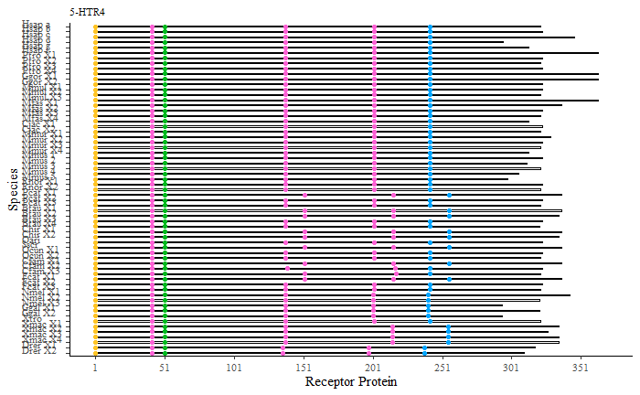

```r
  # plot

   HTR4_motif_plot <-
    ggplot() +
    scale_y_continuous(breaks = seq(1, 370, 50)) +
    geom_bar(data = HTR4_vert_data, aes(x = Species, y = Mod_Length), stat = "identity", width = 0.2, col = "black", fill = "white") +
    geom_point(data = HTR4_vert_data, aes(x = Species, y = Mod_D2.50, colour = "D2.50"), show.legend = FALSE) +
    geom_point(data = HTR4_vert_data, aes(x =  Species, y = Mod_D3.49, colour = "D3.49"), show.legend = FALSE) +
    geom_point(data = HTR4_vert_data, aes(x =  Species, y = Mod_N7.49, colour = "N7.49"), show.legend = FALSE) +
    geom_point(data = HTR4_vert_data, aes(x =  Species, y = Mod_I3.40, colour = "I3.40"), show.legend = FALSE) +
    geom_point(data = HTR4_vert_data, aes(x =  Species, y = Mod_P5.50, colour = "P5.50"), show.legend = FALSE) +
    geom_point(data = HTR4_vert_data, aes(x =  Species, y = Mod_F6.44, colour = "F6.44"), show.legend = FALSE) +
    scale_color_manual(values = c("D3.49" = "#00B81F", "N7.49" = "#00A5FF", "D2.50" = "#FFC425", "I3.40" = "#FC61D5", "P5.50" = "#FC61D5", "F6.44" = "#FC61D5"))+
    theme_tufte() +
    theme(axis.line = element_line(),
          axis.text.x = element_text(size = 8),
          axis.text.y = element_text(size = 8, hjust = 0, vjust = 0),
          plot.title = element_text(size = 8),
          panel.background = element_blank(),
          legend.text = element_blank(),
          legend.title = element_blank()) +
    labs(title = "5-HTR4", y ="Receptor Protein") +
    coord_flip(ylim = c(1, 370)) +
    scale_x_discrete(limits = rev(levels(HTR4_vert_data$Species)))


   HTR4_motif_plot
```

# Moitf Figures

- 1A, 2A and 6 are main figure (p4)
- rest goes to supplementary

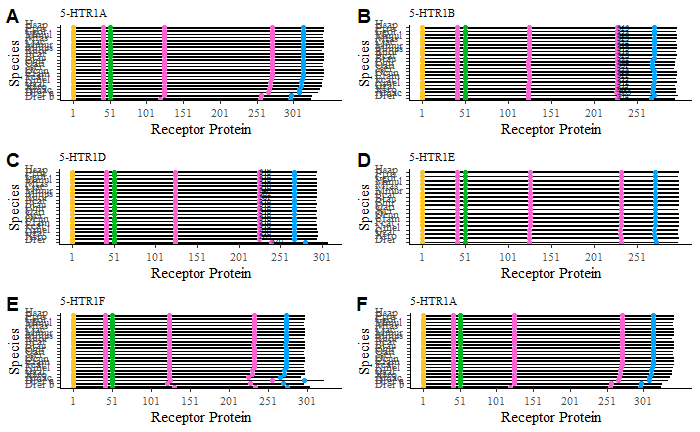

```r
# motif plots

# G alpha i
p1plot <- plot_grid(HTR1A_motif_plot, HTR1B_motif_plot,
                      HTR1D_motif_plot, HTR1E_motif_plot,
                      HTR1F_motif_plot, HTR1A_motif_plot,
                      labels = c("A", "B", "C", "D", "E", "F"),
                      ncol = 2, nrow = 3)

  p1plot

  ggsave(file="output/p1plot.pdf", width = 210, height = 297, units = "mm")
```

```r
  # G alpha q and htr6

  p2plot <- plot_grid(HTR2A_motif_plot,
                      HTR2B_motif_plot,
                      HTR2C_motif_plot,
                      HTR6_motif_plot,
                      labels = c("A", "B", "C", "D"),
                      ncol = 2, nrow = 2)
```

```
Removed 5 rows containing missing values (geom_point).Removed 1 rows containing missing values (geom_point).
```

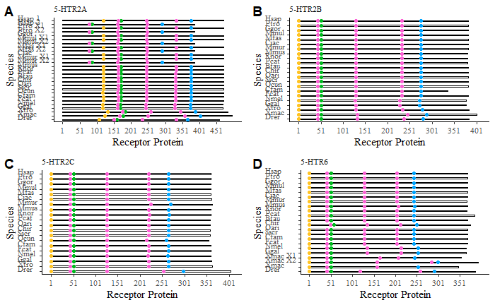

```r
  p2plot

  ggsave(file="output/p2plot.pdf", width = 210, height = 297, units = "mm")
```

```r
  # htr4 and htr7

  p3plot <- plot_grid(HTR4_motif_plot,
                      HTR7_motif_plot,
                      labels = c("A", "B"),
                      ncol = 1, nrow = 2)
```

```
Removed 1 rows containing missing values (geom_point).
```

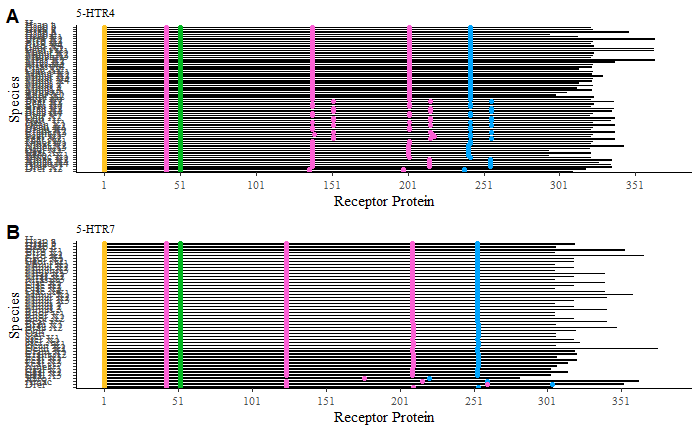

```r
  p3plot

  ggsave(file="output/p3plot.pdf", width = 210, height = 297, units = "mm")
```

```r
  # 1a, 2a, 6

  p4plot <- plot_grid(HTR1A_motif_plot,
                      HTR2A_motif_plot,
                      HTR6_motif_plot,
                      labels = c("a", "b", "c"),
                      ncol = 1, nrow = 3)
```

```
Removed 5 rows containing missing values (geom_point).Removed 1 rows containing missing values (geom_point).
```

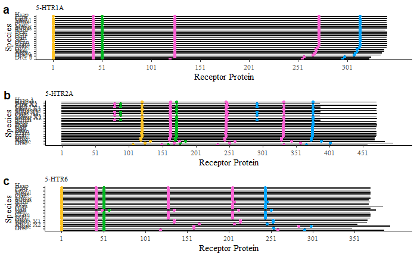

```r
  p4plot

  ggsave(file="output/p4plot.pdf", width = 210, height = 297, units = "mm")
```

```r
NA
```

# Time Tree

- Using ggtree
- Pre-analysis: prepping the input from the .tre file by manually renaming the taxa. Of course this will create duplicates as I will remove the receptor prefix from each taxa and it will just be species names. So it will no longer be read by Figtree. I will load every step of manually edited .tre in R
- revts() is not working after updating so I shifted revts before the geom_hilight()

```r
# install.views('Phylogenetics')

   update.views('Phylogenetics')
```

[output not shown]

[output not shown]

|  | binary | source | needs_compilation |
| --- | --- | --- | --- |
| DDD | 4.4.1 | 5.0 | TRUE |

```
  Binaries will be installed
```

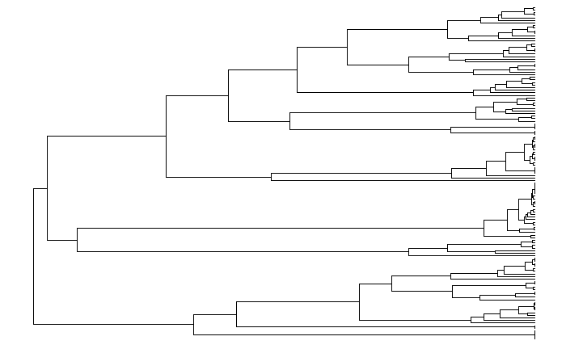

```r
# plotting

   ## mrds for the time scale

   ## geom_tippoint to colour tips

   ## scale colour for a nice paletter

   ## geom_label2 to label heights of every node

   ## geom_nodelab to label posterior along the branch

   ## geom_hilight to highlight clades

   ## theme_tree2() to get the time tree

   ## theme() to place the legend of the tip points and to font size

   ## labs to caption

# Strict clock

  # pre- step 1: prep the beast file.

  ## once you make duplicates of tip labels there is no more opening of it in figtree.

  ## make sure both taxa name and the phylogenetic data are changed

  ## load at every stage to make sure it's alright.

  # pre- step 2: reading the tree file

   strict_tree <- read.beast(file="input/1994_str_30M_4_MRCA_thin2.tre")

  # step 1: plotting just the branches

    plot1 <- ggtree(strict_tree, layout = "rectangular")

    plot(plot1)
```

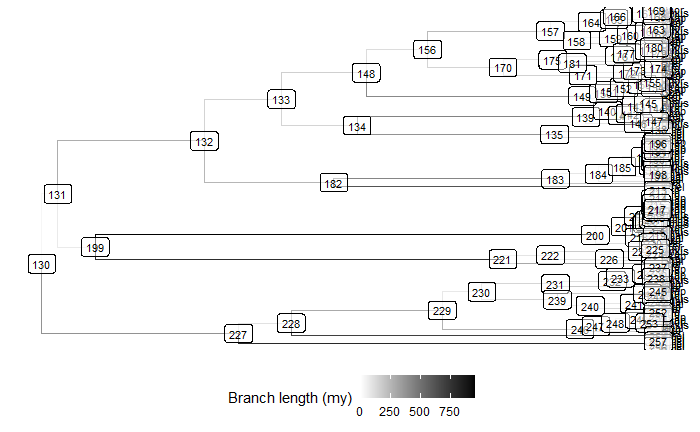

```r
  # step 2: finding the key nodes

    ## check with the PDF from the figtree output

    plot2 <- ggtree(strict_tree, aes( color = branch.length)) +
    geom_tiplab(size =3, color="black") +
    geom_label2(aes(subset=!isTip, label=node), size =3, color="black", alpha=0.5) +
    scale_color_continuous(low='white', high='black', name="Branch length (my)") +
    theme(legend.position="bottom")

    plot(plot2)
```

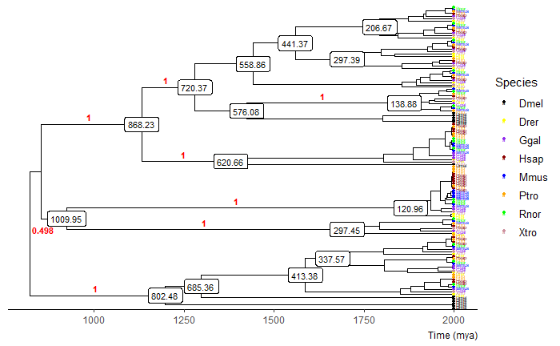

```r
   # step 3: plotting the tree,

    plot3 <- ggtree(strict_tree, right = FALSE, mrsd="2000-01-01") +
      geom_tippoint(aes(color= label), shape = 16, size= 1.2, position = "identity") +
      geom_tiplab(aes(color= label), size = 1.5) +
      scale_color_manual(values=c("black", "yellow", "purple2", "darkred", "blue", "orange", "green", "pink3")) +
      labs(colour = "Species") +
      geom_label2(aes(subset= node == 133, label= round(height, 2)), size =3, color="black") +
      geom_label2(aes(subset= node == 132, label= round(height, 2)), size =3, color="black") +
      geom_label2(aes(subset= node == 139, label= round(height, 2)), size =3, color="black") +
      geom_label2(aes(subset= node == 182, label= round(height, 2)), size =3, color="black") +
      geom_label2(aes(subset= node == 200, label= round(height, 2)), size =3, color="black") +
      geom_label2(aes(subset= node == 221, label= round(height, 2)), size =3, color="black") +
      geom_label2(aes(subset= node == 227, label= round(height, 2)), size =3, color="black") +
      geom_label2(aes(subset= node == 148, label= round(height, 2)), size =3, color="black") +
      geom_label2(aes(subset= node == 156, label= round(height, 2)), size =3, color="black") +
      geom_label2(aes(subset= node == 157, label= round(height, 2)), size =3, color="black") +
      geom_label2(aes(subset= node == 170, label= round(height, 2)), size =3, color="black") +
      geom_label2(aes(subset= node == 134, label= round(height, 2)), size =3, color="black") +
      geom_label2(aes(subset= node == 228, label= round(height, 2)), size =3, color="black") +
      geom_label2(aes(subset= node == 229, label= round(height, 2)), size =3, color="black") +
      geom_label2(aes(subset= node == 230, label= round(height, 2)), size =3, color="black") +
      geom_label2(aes(subset= node == 199, label= round(height, 2)), size =3, color="black") +
      geom_nodelab(aes(x=branch, subset= node == 133, label= round(posterior, 3)), vjust=-.5, hjust = 1, size =3, color = "red", fontface = "bold") +
      geom_nodelab(aes(x=branch, subset= node == 132, label= round(posterior, 3)), vjust=-.5, hjust = 1, size =3, color = "red", fontface = "bold") +
      geom_nodelab(aes(x=branch, subset= node == 139, label=round(posterior, 3)), vjust=-.5, hjust = 1, size =3, color = "red", fontface = "bold") +
      geom_nodelab(aes(x=branch, subset= node == 182, label=round(posterior, 3)), vjust=-.5, hjust = 1, size =3, color = "red", fontface = "bold") +
      geom_nodelab(aes(x=branch, subset= node == 200, label=round(posterior, 3)), vjust=-.5, hjust = 1, size =3, color = "red", fontface = "bold") +
      geom_nodelab(aes(x=branch, subset= node == 221, label=round(posterior, 3)), vjust=-.5, hjust = 1, size =3, color = "red", fontface = "bold") +
      geom_nodelab(aes(x=branch, subset= node == 227, label=round(posterior, 3)), vjust=-.5, hjust = 1, size =3, color = "red", fontface = "bold") +
      geom_nodelab(aes(x=branch, subset= node == 199, label=round(posterior, 3)), vjust= 2, hjust =1, size =3, color = "red", fontface = "bold") +
      theme_tree2() +
      theme(legend.position="right", legend.text = element_text(size = 10)) +
      labs(caption="Time (mya)")

    plot(plot3)
```

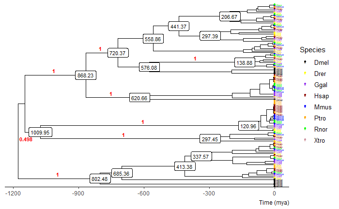

```r
    # step 4: flipping the time axis

    plot4 <- revts(plot3)

    plot(plot4)
```

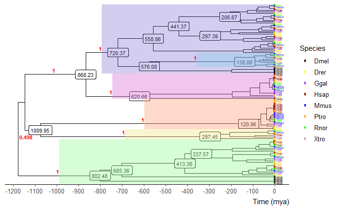

```r
    # step 5: scaling it nicely + highlighting clades

    plot5 <- plot4 +
      geom_hilight(node=133, fill="slateblue", alpha=0.3) +
      geom_hilight(node=139, fill="skyblue", alpha=0.4) +
      geom_hilight(node=182, fill="orchid", alpha=0.4) +
      geom_hilight(node=200, fill="lightsalmon", alpha=0.4) +
      geom_hilight(node=221, fill="khaki", alpha=0.4) +
      geom_hilight(node=227, fill="palegreen", alpha=0.4) +
      scale_x_continuous(breaks = c(-1200, -1100, -1000, -900, -800, -700, -600, -500, -400, -300, -200, -100, 0)) +
      theme(axis.text.x = element_text(size = 10), plot.caption = element_text(size =11))

    plot(plot5)
```

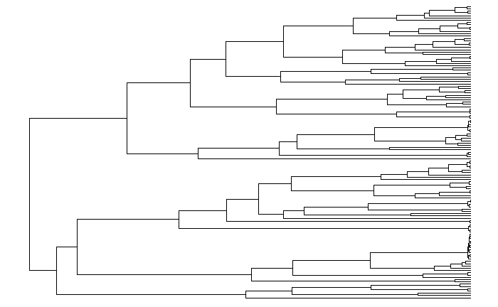

```r
  # post step 1:
  ## label the clades

# exponential clock

  # step 1

    expo_tree <- read.beast(file="input/1994_rlxE_50M_4_MRCA_thin2.tre")

  # step 1

    plot6 <- ggtree(expo_tree, layout = "rectangular")

    plot(plot6)
```

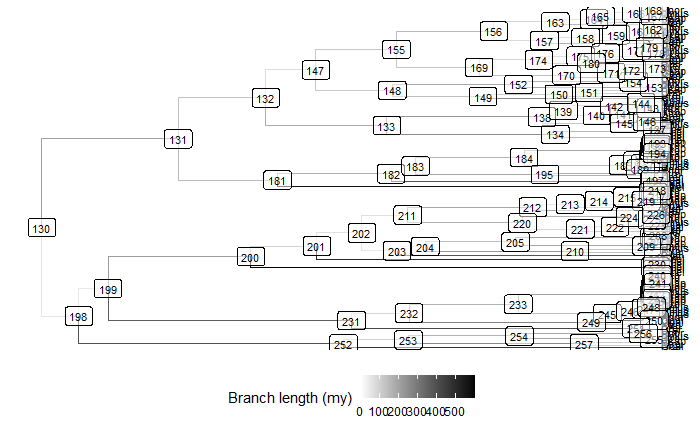

```r
  # step 2

    plot7 <- ggtree(expo_tree, aes( color = branch.length)) +
    geom_tiplab(size =3, color="black") +
    geom_label2(aes(subset=!isTip, label=node), size =3, color="black", alpha=0.5) +
    scale_color_continuous(low='white', high='black', name="Branch length (my)") +
    theme(legend.position="bottom")

    plot(plot7)
```

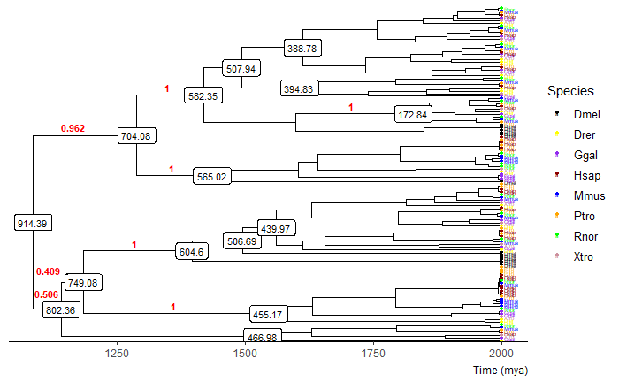

```r
  # step 3

    plot8 <- ggtree(expo_tree, right = FALSE, mrsd="2000-01-01") +
      geom_tippoint(aes(color= label), shape = 16, size= 1.2, position = "identity") +
      geom_tiplab(aes(color= label), size = 1.5) +
      scale_color_manual(values=c("black", "yellow", "purple2", "darkred", "blue", "orange", "green", "pink3", "pink2")) +
      labs(colour = "Species") +
      geom_label2(aes(subset= node == 132, label= round(height, 2)), size =3, color="black") +
    geom_label2(aes(subset= node == 131, label= round(height, 2)), size =3, color="black") +
    geom_label2(aes(subset= node == 138, label= round(height, 2)), size =3, color="black") +
    geom_label2(aes(subset= node == 181, label= round(height, 2)), size =3, color="black") +
    geom_label2(aes(subset= node == 200, label= round(height, 2)), size =3, color="black") +
    geom_label2(aes(subset= node == 231, label= round(height, 2)), size =3, color="black") +
    geom_label2(aes(subset= node == 252, label= round(height, 2)), size =3, color="black") +
    geom_label2(aes(subset= node == 199, label= round(height, 2)), size =3, color="black") +
    geom_label2(aes(subset= node == 130, label= round(height, 2)), size =3, color="black") +
    geom_label2(aes(subset= node == 200, label= round(height, 2)), size =3, color="black") +
    geom_label2(aes(subset= node == 201, label= round(height, 2)), size =3, color="black") +
    geom_label2(aes(subset= node == 202, label= round(height, 2)), size =3, color="black") +
    geom_label2(aes(subset= node == 147, label= round(height, 2)), size =3, color="black") +
    geom_label2(aes(subset= node == 155, label= round(height, 2)), size =3, color="black") +
    geom_label2(aes(subset= node == 148, label= round(height, 2)), size =3, color="black") +
    geom_label2(aes(subset= node == 198, label= round(height, 2)), size =3, color="black") +
    geom_nodelab(aes(x=branch, subset= node == 132, label= round(posterior, 3)), vjust=-.5, hjust = 1, size =3, color = "red", fontface = "bold") +
    geom_nodelab(aes(x=branch, subset= node == 131, label= round(posterior, 3)), vjust=-.5, hjust = 1, size =3, color = "red", fontface = "bold") +
    geom_nodelab(aes(x=branch, subset= node == 138, label=round(posterior, 3)), vjust=-.5, hjust = 1, size =3, color = "red", fontface = "bold") +
    geom_nodelab(aes(x=branch, subset= node == 181, label=round(posterior, 3)), vjust=-.5, hjust = 1, size =3, color = "red", fontface = "bold") +
    geom_nodelab(aes(x=branch, subset= node == 199, label=round(posterior, 3)), vjust= -1, hjust = 1.5, size =3, color = "red", fontface = "bold") +
    geom_nodelab(aes(x=branch, subset= node == 200, label=round(posterior, 3)), vjust=-.5, hjust = 1, size =3, color = "red", fontface = "bold") +
    geom_nodelab(aes(x=branch, subset= node == 231, label=round(posterior, 3)), vjust=-.5, hjust = 1, size =3, color = "red", fontface = "bold") +
    geom_nodelab(aes(x=branch, subset= node == 252, label=round(posterior, 3)), vjust= 2, hjust =1, size =3, color = "red", fontface = "bold") +
    geom_nodelab(aes(x=branch, subset= node == 198, label=round(posterior, 3)), vjust= -1.5, hjust =.5, size =3, color = "red", fontface = "bold") +
    theme_tree2() +
    theme(legend.position="right", legend.text = element_text(size = 10)) +
    labs(caption="Time (mya)")

  plot(plot8)
```

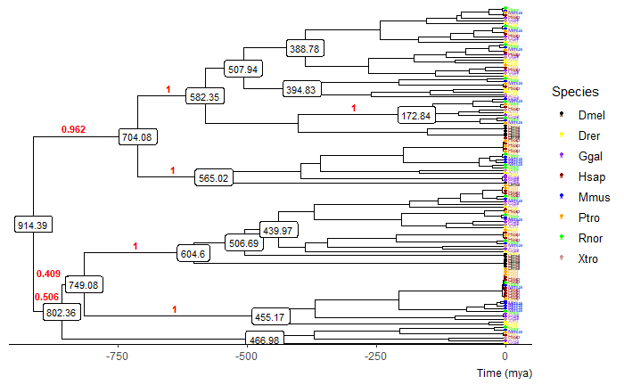

```r
  # step 4: flipping the time axis

  plot9 <- revts(plot8)

  plot(plot9)
```

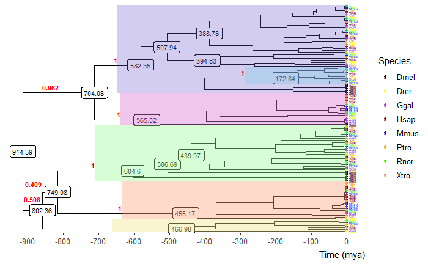

```r
  # step 5: scaling it nicely + highlighting clades
  plot10 <- plot9 +
    geom_hilight(node=132, fill="slateblue", alpha=0.3) +
    geom_hilight(node=138, fill="skyblue", alpha=0.4) +
    geom_hilight(node=181, fill="orchid", alpha=0.4) +
    geom_hilight(node=200, fill="palegreen", alpha=0.4) +
    geom_hilight(node=231, fill="lightsalmon", alpha=0.4) +
    geom_hilight(node=252, fill="khaki", alpha=0.4) +
    scale_x_continuous(breaks = c(-1000, -900, -800, -700, -600, -500, -400, -300, -200, -100, 0)) +
    theme(axis.text.x = element_text(size = 10), plot.caption = element_text(size =11))

  plot(plot10)
```

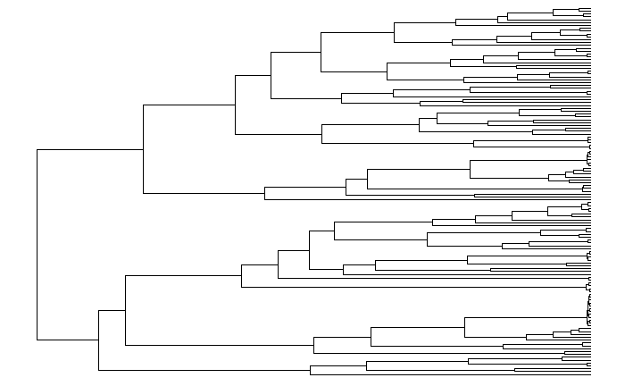

```r
# lognormal tree

  log_tree <- read.beast(file="input/1994_rlxL_55M_5_MRCA_thin2.tre")

  # step 1

    plot11 <- ggtree(log_tree, layout = "rectangular")

    plot(plot11)
```

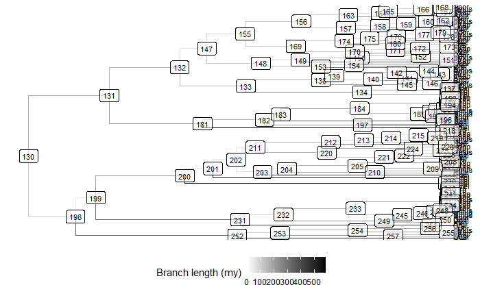

```r
  # step 2

    plot12 <- ggtree(log_tree, aes( color = branch.length)) +
    geom_tiplab(size =3, color="black") +
    geom_label2(aes(subset=!isTip, label=node), size =3, color="black", alpha=0.5) +
    scale_color_continuous(low='white', high='black', name="Branch length (my)") +
    theme(legend.position="bottom")

  plot(plot12)
```

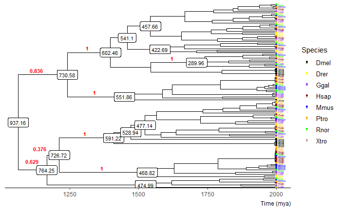

```r
  # step 3

  plot13 <- ggtree(log_tree, right = FALSE, mrsd="2000-01-01") +
    geom_tippoint(aes(color= label), shape = 16, size= 1.2, position = "identity") +
    geom_tiplab(aes(color= label), size = 1.5) +
    scale_color_manual(values=c("black", "yellow", "purple2", "darkred", "blue", "orange", "green", "pink3", "pink2")) +
    labs(colour = "Species") +
    geom_label2(aes(subset= node == 132, label= round(height, 2)), size =3, color="black") +
    geom_label2(aes(subset= node == 131, label= round(height, 2)), size =3, color="black") +
    geom_label2(aes(subset= node == 138, label= round(height, 2)), size =3, color="black") +
    geom_label2(aes(subset= node == 181, label= round(height, 2)), size =3, color="black") +
    geom_label2(aes(subset= node == 200, label= round(height, 2)), size =3, color="black") +
    geom_label2(aes(subset= node == 231, label= round(height, 2)), size =3, color="black") +
    geom_label2(aes(subset= node == 252, label= round(height, 2)), size =3, color="black") +
    geom_label2(aes(subset= node == 199, label= round(height, 2)), size =3, color="black") +
    geom_label2(aes(subset= node == 130, label= round(height, 2)), size =3, color="black") +
    geom_label2(aes(subset= node == 200, label= round(height, 2)), size =3, color="black") +
    geom_label2(aes(subset= node == 201, label= round(height, 2)), size =3, color="black") +
    geom_label2(aes(subset= node == 202, label= round(height, 2)), size =3, color="black") +
    geom_label2(aes(subset= node == 147, label= round(height, 2)), size =3, color="black") +
    geom_label2(aes(subset= node == 155, label= round(height, 2)), size =3, color="black") +
    geom_label2(aes(subset= node == 148, label= round(height, 2)), size =3, color="black") +
    geom_label2(aes(subset= node == 198, label= round(height, 2)), size =3, color="black") +
    geom_nodelab(aes(x=branch, subset= node == 132, label= round(posterior, 3)), vjust=-.5, hjust = 1, size =3, color = "red", fontface = "bold") +
    geom_nodelab(aes(x=branch, subset= node == 131, label= round(posterior, 3)), vjust=-.5, hjust = 1, size =3, color = "red", fontface = "bold") +
    geom_nodelab(aes(x=branch, subset= node == 138, label=round(posterior, 3)), vjust=-.5, hjust = 1, size =3, color = "red", fontface = "bold") +
    geom_nodelab(aes(x=branch, subset= node == 181, label=round(posterior, 3)), vjust=-.5, hjust = 1, size =3, color = "red", fontface = "bold") +
    geom_nodelab(aes(x=branch, subset= node == 199, label=round(posterior, 3)), vjust= -1, hjust = 1.5, size =3, color = "red", fontface = "bold") +
    geom_nodelab(aes(x=branch, subset= node == 200, label=round(posterior, 3)), vjust=-.5, hjust = 1, size =3, color = "red", fontface = "bold") +
    geom_nodelab(aes(x=branch, subset= node == 231, label=round(posterior, 3)), vjust=-.5, hjust = 1, size =3, color = "red", fontface = "bold") +
    geom_nodelab(aes(x=branch, subset= node == 252, label=round(posterior, 3)), vjust= 2, hjust =1, size =3, color = "red", fontface = "bold") +
    geom_nodelab(aes(x=branch, subset= node == 198, label=round(posterior, 3)), vjust= -1.5, hjust =.5, size =3, color = "red", fontface = "bold") +
    theme_tree2() +
    theme(legend.position="right", legend.text = element_text(size = 10)) +
    labs(caption="Time (mya)")

  plot(plot13)
```

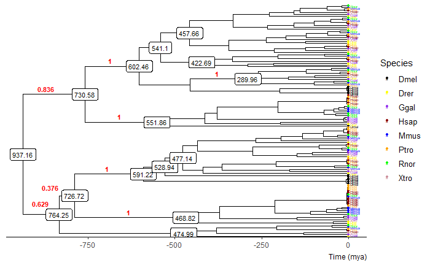

```r
  # step 4: flipping the time axis

  plot14 <- revts(plot13)

  plot(plot14)
```

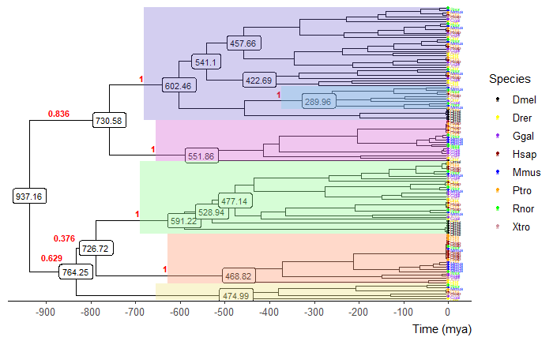

```r
  # step 5: scaling it nicely + highlighting clades

  plot15 <- plot14 +
    geom_hilight(node=132, fill="slateblue", alpha=0.3) +
    geom_hilight(node=138, fill="skyblue", alpha=0.4) +
    geom_hilight(node=181, fill="orchid", alpha=0.4) +
    geom_hilight(node=200, fill="palegreen", alpha=0.4) +
    geom_hilight(node=231, fill="lightsalmon", alpha=0.4) +
    geom_hilight(node=252, fill="khaki", alpha=0.4) +
    scale_x_continuous(breaks = c(-1000, -900, -800, -700, -600, -500, -400, -300, -200, -100, 0)) +
    theme(axis.text.x = element_text(size = 10), plot.caption = element_text(size =11))

  plot(plot15)
```

# Plots for publication

- PDF format
- Legends for nodes added with the PDF
- lognormal is the main figure, exponential and strict in the supplementary

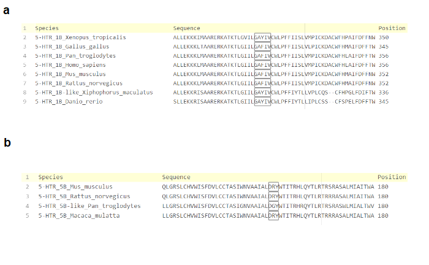

```r
# trees

## strict clock

  ggsave(file ="output/stricttree.pdf", plot = plot5, width = 297, height = 210, units = "mm")

## relaxed exponential clock

  ggsave(file ="output/expotree.pdf", plot = plot10, width = 297, height = 210, units = "mm")

  ## relaxed lognormal clock

  ggsave(file ="output/logtree.pdf", plot = plot15, width = 297, height = 210, units = "mm")

# motifs

  fswitch <- cowplot::ggdraw() + cowplot::draw_image("input/Fswitch.PNG", scale = 0.9)

  rswitch <- cowplot::ggdraw() + cowplot::draw_image("input/Rswitch.PNG", scale = 0.9)

  switches <- plot_grid(fswitch,
                        rswitch,
                        labels = c("a", "b"),
                        ncol = 1,
                        nrow = 2)

  switches

  ggsave("output/switches.pdf", width = 20, height = 13, units = "cm")
```

```r
NA
NA
```

# Similarty and identity

```r
  vert_PA_data <- HTR_vert_data %>%
    select (Receptor, Species, Identity, Similarity)

  # filtering out human values with !=

  vert_PA_data <- vert_PA_data %>% filter(Species != "Hsap")

  # filtering the all_PA_data, first getting species, min, iden col for the min value, next getting the same cols for the max value, then binding those two with c bind, then binding all receptors with rbind.  generate columns for mean values by summarise (mean = mean()) only for deleting later

  vert_PA_summary <-

    rbind(

      cbind (

        vert_PA_data %>% filter (Receptor == "5-HTR1A") %>%
          filter (Identity %in% min(Identity)),

        vert_PA_data %>% filter (Receptor == "5-HTR1A") %>%
          filter (Identity %in% max(Identity)),

        vert_PA_data  %>% filter(Receptor == "5-HTR1A" ) %>% summarise (mean = mean(Identity)),

        vert_PA_data  %>% filter(Receptor == "5-HTR1A" ) %>% summarise (mean = mean(Similarity))
      ),

      cbind (
        vert_PA_data %>% filter (Receptor == "5-HTR1B") %>%
          filter (Identity %in% min(Identity)),

        vert_PA_data %>% filter (Receptor == "5-HTR1B") %>%
          filter (Identity %in% max(Identity)),

        vert_PA_data  %>% filter(Receptor == "5-HTR1B" ) %>% summarise (mean = mean(Identity)),

        vert_PA_data  %>% filter(Receptor == "5-HTR1B" ) %>% summarise (mean = mean(Similarity))
      ),

      cbind (
        vert_PA_data %>% filter (Receptor == "5-HTR1D") %>%
          filter (Identity %in% min(Identity)),

        vert_PA_data %>% filter (Receptor == "5-HTR1D") %>%
          filter (Identity %in% max(Identity)),

        vert_PA_data  %>% filter(Receptor == "5-HTR1D" ) %>% summarise (mean = mean(Identity)),

        vert_PA_data  %>% filter(Receptor == "5-HTR1D" ) %>% summarise (mean = mean(Similarity))
      ),

      cbind (
        vert_PA_data %>% filter (Receptor == "5-HTR1E") %>%
          filter (Identity %in% min(Identity)),

        vert_PA_data %>% filter (Receptor == "5-HTR1E") %>%
          filter (Identity %in% max(Identity)),

        vert_PA_data  %>% filter(Receptor == "5-HTR1E" ) %>% summarise (mean = mean(Identity)),

        vert_PA_data  %>% filter(Receptor == "5-HTR1E" ) %>% summarise (mean = mean(Similarity))
      ),

      cbind (
        vert_PA_data %>% filter (Receptor == "5-HTR1F") %>%
          filter (Identity %in% min(Identity)),

        vert_PA_data %>% filter (Receptor == "5-HTR1F") %>%
          filter (Identity %in% max(Identity)),

        vert_PA_data  %>% filter(Receptor == "5-HTR1F" ) %>% summarise (mean = mean(Identity)),

        vert_PA_data  %>% filter(Receptor == "5-HTR1F" ) %>% summarise (mean = mean(Similarity))
      ),

      cbind (

        vert_PA_data %>% filter (Receptor == "5-HTR5A") %>%
          filter (Identity %in% min(Identity)),

        vert_PA_data %>% filter (Receptor == "5-HTR5A") %>%
          filter (Identity %in% max(Identity)),

        vert_PA_data  %>% filter(Receptor == "5-HTR5A" ) %>% summarise (mean = mean(Identity)),

        vert_PA_data  %>% filter(Receptor == "5-HTR5A" ) %>% summarise (mean = mean(Similarity))
      ),

      cbind (

        vert_PA_data %>% filter (Receptor == "5-HTR5B") %>%
          filter (Identity %in% min(Identity)),

        vert_PA_data %>% filter (Receptor == "5-HTR5B") %>%
          filter (Identity %in% max(Identity)),

        vert_PA_data  %>% filter(Receptor == "5-HTR5B" ) %>% summarise (mean = mean(Identity)),

        vert_PA_data  %>% filter(Receptor == "5-HTR5B" ) %>% summarise (mean = mean(Similarity))
      ),
      cbind (

        vert_PA_data %>% filter (Receptor == "5-HTR2A") %>%
          filter (Identity %in% min(Identity)),

        vert_PA_data %>% filter (Receptor == "5-HTR2A") %>%
          filter (Identity %in% max(Identity)),

        vert_PA_data  %>% filter(Receptor == "5-HTR2A" ) %>% summarise (mean = mean(Identity)),

        vert_PA_data  %>% filter(Receptor == "5-HTR2A" ) %>% summarise (mean = mean(Similarity))
      ),

      cbind (

        vert_PA_data %>% filter (Receptor == "5-HTR2B") %>%
          filter (Identity %in% min(Identity)),

        vert_PA_data %>% filter (Receptor == "5-HTR2B") %>%
          filter (Identity %in% max(Identity)),

        vert_PA_data  %>% filter(Receptor == "5-HTR2B" ) %>% summarise (mean = mean(Identity)),

        vert_PA_data  %>% filter(Receptor == "5-HTR2B" ) %>% summarise (mean = mean(Similarity))
      ),

      cbind (

        vert_PA_data %>% filter (Receptor == "5-HTR2C") %>%
          filter (Identity %in% min(Identity)),

        vert_PA_data %>% filter (Receptor == "5-HTR2C") %>%
          filter (Identity %in% max(Identity)),

        vert_PA_data  %>% filter(Receptor == "5-HTR2C" ) %>% summarise (mean = mean(Identity)),

        vert_PA_data  %>% filter(Receptor == "5-HTR2C" ) %>% summarise (mean = mean(Similarity))
      ),

      cbind (

        vert_PA_data %>% filter (Receptor == "5-HTR4") %>%
          filter (Identity %in% min(Identity)),

        vert_PA_data %>% filter (Receptor == "5-HTR4") %>%
          filter (Identity %in% max(Identity)),

        vert_PA_data  %>% filter(Receptor == "5-HTR4" ) %>% summarise (mean = mean(Identity)),

        vert_PA_data  %>% filter(Receptor == "5-HTR4" ) %>% summarise (mean = mean(Similarity))
      ),

      cbind (

        vert_PA_data %>% filter (Receptor == "5-HTR6") %>%
          filter (Identity %in% min(Identity)),

        vert_PA_data %>% filter (Receptor == "5-HTR6") %>%
          filter (Identity %in% max(Identity)),

        vert_PA_data  %>% filter(Receptor == "5-HTR6" ) %>% summarise (mean = mean(Identity)),

        vert_PA_data  %>% filter(Receptor == "5-HTR6" ) %>% summarise (mean = mean(Similarity))
      ),

      cbind (

        vert_PA_data %>% filter (Receptor == "5-HTR7") %>%
          filter (Identity %in% min(Identity)),

        vert_PA_data %>% filter (Receptor == "5-HTR7") %>%
          filter (Identity %in% max(Identity)),

        vert_PA_data  %>% filter(Receptor == "5-HTR7" ) %>% summarise (mean = mean(Identity)),

        vert_PA_data  %>% filter(Receptor == "5-HTR7" ) %>% summarise (mean = mean(Similarity))
      )

    )

  vert_PA_summary
```

| Receptor | Species | Identity | Similarity | Receptor | Species | Identity | Similarity | mean | mean |
| --- | --- | --- | --- | --- | --- | --- | --- | --- | --- |
| 5-HTR1A | Drer | 65.9 | 75.5 | 5-HTR1A | Ggor | 99.8 | 99.8 | 88.45455 | 91.68636 |
| 5-HTR1B | Drer | 64.7 | 76.7 | 5-HTR1B | Ptro | 100.0 | 100.0 | 89.24762 | 92.93333 |
| 5-HTR1D | Drer | 66.5 | 77.9 | 5-HTR1D | Ptro | 99.5 | 99.7 | 88.54000 | 92.32000 |
| 5-HTR1E | Drer | 64.6 | 77.2 | 5-HTR1E | Ptro | 100.0 | 100.0 | 92.05882 | 95.43529 |
| 5-HTR1E | Drer | 64.6 | 77.2 | 5-HTR1E | Ggor | 100.0 | 100.0 | 92.05882 | 95.43529 |
| 5-HTR1F | Xmac | 54.8 | 68.6 | 5-HTR1F | Ptro | 100.0 | 100.0 | 88.26364 | 93.34091 |
| 5-HTR5A | Xtro | 74.5 | 84.4 | 5-HTR5A | Ggor | 99.2 | 99.4 | 87.52222 | 92.21111 |
| 5-HTR5B | Chir | 85.0 | 89.3 | 5-HTR5B | Ptro | 100.0 | 100.0 | 89.57273 | 92.20000 |
| 5-HTR2A | Drer | 55.1 | 66.7 | 5-HTR2A | Ggor | 100.0 | 100.0 | 90.19200 | 93.50400 |
| 5-HTR2B | Xmac | 54.7 | 67.1 | 5-HTR2B | Ggor | 99.8 | 100.0 | 84.30690 | 88.47931 |

[output cut: 6 more lines]

```r
  vert_PA_summary
```

| Receptor | Species | Identity | Similarity | Receptor | Species | Identity | Similarity | mean | mean |
| --- | --- | --- | --- | --- | --- | --- | --- | --- | --- |
| 5-HTR1A | Drer | 65.9 | 75.5 | 5-HTR1A | Ggor | 99.8 | 99.8 | 88.45455 | 91.68636 |
| 5-HTR1B | Drer | 64.7 | 76.7 | 5-HTR1B | Ptro | 100.0 | 100.0 | 89.24762 | 92.93333 |
| 5-HTR1D | Drer | 66.5 | 77.9 | 5-HTR1D | Ptro | 99.5 | 99.7 | 88.54000 | 92.32000 |
| 5-HTR1E | Drer | 64.6 | 77.2 | 5-HTR1E | Ptro | 100.0 | 100.0 | 92.05882 | 95.43529 |
| 5-HTR1E | Drer | 64.6 | 77.2 | 5-HTR1E | Ggor | 100.0 | 100.0 | 92.05882 | 95.43529 |
| 5-HTR1F | Xmac | 54.8 | 68.6 | 5-HTR1F | Ptro | 100.0 | 100.0 | 88.26364 | 93.34091 |
| 5-HTR5A | Xtro | 74.5 | 84.4 | 5-HTR5A | Ggor | 99.2 | 99.4 | 87.52222 | 92.21111 |
| 5-HTR5B | Chir | 85.0 | 89.3 | 5-HTR5B | Ptro | 100.0 | 100.0 | 89.57273 | 92.20000 |
| 5-HTR2A | Drer | 55.1 | 66.7 | 5-HTR2A | Ggor | 100.0 | 100.0 | 90.19200 | 93.50400 |
| 5-HTR2B | Xmac | 54.7 | 67.1 | 5-HTR2B | Ggor | 99.8 | 100.0 | 84.30690 | 88.47931 |

[output cut: 6 more lines]

```r
  # removing tail columns

  vert_PA_summary_rd <- vert_PA_summary[,-c(10)]

  vert_PA_summary_rd <- vert_PA_summary_rd [,-c(9)]

  # removing the middle colummn

  vert_PA_summary_rd <- vert_PA_summary_rd [,-c(5)]

  vert_PA_summary_rd
```

| Receptor | Species | Identity | Similarity | Species.1 | Identity.1 | Similarity.1 |
| --- | --- | --- | --- | --- | --- | --- |
| 5-HTR1A | Drer | 65.9 | 75.5 | Ggor | 99.8 | 99.8 |
| 5-HTR1B | Drer | 64.7 | 76.7 | Ptro | 100.0 | 100.0 |
| 5-HTR1D | Drer | 66.5 | 77.9 | Ptro | 99.5 | 99.7 |
| 5-HTR1E | Drer | 64.6 | 77.2 | Ptro | 100.0 | 100.0 |
| 5-HTR1E | Drer | 64.6 | 77.2 | Ggor | 100.0 | 100.0 |
| 5-HTR1F | Xmac | 54.8 | 68.6 | Ptro | 100.0 | 100.0 |
| 5-HTR5A | Xtro | 74.5 | 84.4 | Ggor | 99.2 | 99.4 |
| 5-HTR5B | Chir | 85.0 | 89.3 | Ptro | 100.0 | 100.0 |
| 5-HTR2A | Drer | 55.1 | 66.7 | Ggor | 100.0 | 100.0 |
| 5-HTR2B | Xmac | 54.7 | 67.1 | Ggor | 99.8 | 100.0 |

[output cut: 6 more lines]

```r
  # renaming header rows with names ()

  names(vert_PA_summary_rd) <- c("Receptor", "Species with the minimum identity%", "Min ident%", "Min sim%", "Species with the maximum identity%", "Max ident%", "Max sim%")


  # removing the duplicate

  vert_PA_summary_rd <- vert_PA_summary_rd [-c(5, 10, 14),]
```